# Day 5: Using Regression to Model Poverty Rates

Adam Slez

# Question 1

Using the code generated over the last several assignments, construct an `sf` object that includes information on the following variables for each state in the contiguous United States:

- H-2A prevalence measured as a percentage of the size of the civilian labor force
- Percentage of the population in poverty
- Percentage of the total population who identify as Hispanic
- Percentage of the total population who identify as single-race non-Hispanic Black
- Percentage of the total population who identify as single-race non-Hispanic American Indian/Alaskan Native
- Percentage of the civilian labor force employed in agriculture, forestry, fishing and hunting, and mining

To complete this task, you will need to join the H-2A `data.frame` to the `sf` object containing the data from the ACS and then create a new variable representing H-2A prevalence by first dividing the number of H-2A workers in each state by the size of the civilian labor force and then multiplying by 100.

```r
#LOAD LIBRARIES
library(tidyverse)
library(lubridate)
```

```r
library(tidycensus)
library(tigris)
library(readxl)
library(here)
library(marginaleffects)

#CLEAN DATA
#h2a
h2a_2021 <- read_xlsx(here("assignments/02-clean-h2a/",
                               "H-2A_Disclosure_Data_FY2021.xlsx")) %>%
  filter(CASE_STATUS %in% c("Determination Issued - Certification",
                            "Determination Issued - Partial Certification"),
         year(EMPLOYMENT_BEGIN_DATE) < 2022,
         year(EMPLOYMENT_END_DATE) > 2020) %>%
  select(abbr = HOUSING_STATE, cert = TOTAL_WORKERS_H2A_CERTIFIED) %>%
  group_by(abbr) %>%
  summarize(h2a_count = sum(cert)) %>%
  filter(!abbr %in% c("PR", "AK", "HI"))

#acs
poverty <- get_acs(geography = "state", table = "B17001", output = "wide") %>%
  select(state = NAME, pov_pop = B17001_001E, pov = B17001_002E) %>%
  mutate(per_pov = (pov / pov_pop) * 100) %>%
  filter(!state %in% c("Alaska", "Hawaii", "District of Columbia", "Puerto Rico"))
```

```
## Loading ACS5 variables for 2021 from table B17001. To cache this dataset for faster access to ACS tables in the future, run this function with `cache_table = TRUE`. You only need to do this once per ACS dataset.
```

```r
race <- get_acs(geography = "state", table = "B03002", output = "wide") %>%
  select(state = NAME,
         totpop = B03002_001E,
         black = B03002_004E,
         aian = B03002_005E,
         hisp = B03002_012E) %>%
  mutate(per_black = (black / totpop) * 100,
         per_aian = (aian / totpop) * 100,
         per_hisp = (hisp / totpop) * 100) %>%
  filter(!state %in% c("Alaska", "Hawaii", "District of Columbia", "Puerto Rico"))
```

```
## Loading ACS5 variables for 2021 from table B03002. To cache this dataset for faster access to ACS tables in the future, run this function with `cache_table = TRUE`. You only need to do this once per ACS dataset.
```

```r
agriculture <- get_acs(geography = "state", table = "C24070", output = "wide") %>%
  select(state = NAME, clf = C24070_001E, ag = C24070_002E) %>%
  mutate(per_ag = (ag / clf) * 100) %>%
  filter(!state %in% c("Alaska", "Hawaii", "District of Columbia", "Puerto Rico"))
```

```
## Loading ACS5 variables for 2021 from table C24070. To cache this dataset for faster access to ACS tables in the future, run this function with `cache_table = TRUE`. You only need to do this once per ACS dataset.
```

```r
#spatial data
state_sf <- states(cb = TRUE) %>%
  right_join(poverty, by = c("NAME" = "state")) %>%
  right_join(race, by = c("NAME" = "state")) %>%
  right_join(agriculture, by = c("NAME" = "state")) %>%
  right_join(h2a_2021, by = c("STUSPS" = "abbr")) %>%
  mutate(per_h2a = (h2a_count / clf) * 100)
```

# Question 2

Use the `ggplot` command to construct a scatterplot depicting the relationship between the poverty and H-2A prevalence. Make sure to include both a linear trend line, as well as a loess line. Given the relatively small number of data points, I would encourage you to use `geom_text` in place of `geom_point`. Describe what you find.

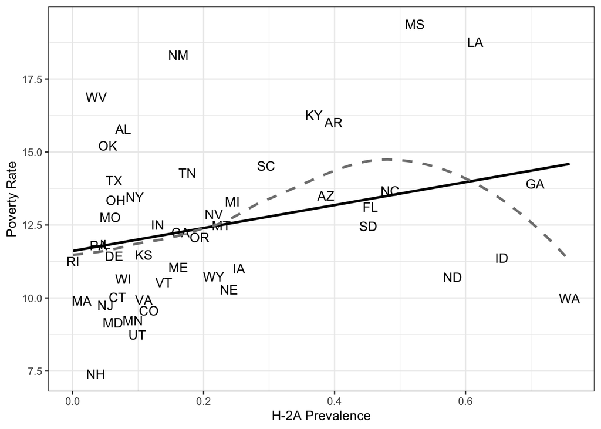

```r
ggplot(data = state_sf, aes(x = per_h2a, y = per_pov, label = STUSPS)) +
  geom_text() +
  geom_smooth(method = "lm", se = FALSE, linetype = 1, color = "black") +
  geom_smooth(method = "loess", se = FALSE, linetype = 2, color = "grey50") +
  scale_x_continuous("H-2A Prevalence") +
  scale_y_continuous("Poverty Rate") +
  theme_bw()
```

The relationship between H-2A prevalence and poverty is unclear. While there is some evidence that the poverty rate is higher in states with a higher concentration of H-2A workers, there are clusters of observations that deviate from this trend. In particular, we observe a number of states in the top-left corner of the graph that have a relatively low concentration of H-2A workers, but have relatively high poverty rights. If we look at the bottom-right corner of the graph, however, we observe a number of states that have a relatively high concentration of H-2A workers and a relatively low poverty rate. This raises the question of whether there is a theoretical reason to expect a curvilinear relationship between H-2A prevalence and poverty or whether deviations from a linear trend can be explained in terms of other observable covariates.

# Question 3

Use the `lm` command to estimate the bivariate regression model associated with the linear trend line from Question 1. Provide a substantive interpretation of both the intercept as well as the slope.

```r
bv_mod <- lm(per_pov ~ per_h2a, data = state_sf)
summary(bv_mod)
```

```
##
## Call:
## lm(formula = per_pov ~ per_h2a, data = state_sf)
##
## Residuals:
##     Min      1Q  Median      3Q     Max
## -4.6045 -1.7874 -0.2897  1.4699  6.0799
##
## Coefficients:
##             Estimate Std. Error t value Pr(>|t|)
## (Intercept)  11.6109     0.5527  21.006   <2e-16 ***
## per_h2a       3.9271     1.8483   2.125    0.039 *
## ---
## Signif. codes:  0 '***' 0.001 '**' 0.01 '*' 0.05 '.' 0.1 ' ' 1
##
## Residual standard error: 2.572 on 46 degrees of freedom
## Multiple R-squared:  0.08937,    Adjusted R-squared:  0.06957
## F-statistic: 4.514 on 1 and 46 DF,  p-value: 0.03902
```

Based on the results, we predict that a state with no H-2A workers would have a poverty rate of roughly 11.6 percent. We find that a one percentage point increase in the size of the H-2A population is associated with a 3.9 percentage point increase in the poverty rate.

# Question 4

Use the `lm` command to estimate a multiple regression model depicting the state poverty rate as a function of the prevalence of H-2A workers, controlling for both racial and ethnic composition, as well as the share of civilian labor force employed in agriculture. Describe what happens to the H-2A coefficient when we control for the other variables? What does this suggest?

```r
mr_mod <- update(bv_mod, . ~ . + per_hisp + per_black + per_aian + per_ag)
summary(mr_mod)
```

```
##
## Call:
## lm(formula = per_pov ~ per_h2a + per_hisp + per_black + per_aian +
##     per_ag, data = state_sf)
##
## Residuals:
##     Min      1Q  Median      3Q     Max
## -5.5814 -1.6426  0.1293  1.0632  6.4691
##
## Coefficients:
##             Estimate Std. Error t value Pr(>|t|)
## (Intercept)  9.31592    0.94606   9.847 1.77e-12 ***
## per_h2a      1.35548    1.83463   0.739 0.464119
## per_hisp     0.02997    0.03311   0.905 0.370579
## per_black    0.16672    0.04209   3.961 0.000284 ***
## per_aian     0.39259    0.20214   1.942 0.058845 .
## per_ag       0.12029    0.22837   0.527 0.601169
## ---
## Signif. codes:  0 '***' 0.001 '**' 0.01 '*' 0.05 '.' 0.1 ' ' 1
##
## Residual standard error: 2.228 on 42 degrees of freedom
## Multiple R-squared:  0.376,  Adjusted R-squared:  0.3018
## F-statistic: 5.062 on 5 and 42 DF,  p-value: 0.001015
```

# Question 5

Use the `ggplot` command to construct an added variable plot depicting the relationship between the poverty and H-2A prevalence, controlling for for (a) racial and ethnic composition and (b) the share of the civilian labor force in agriculture. Make sure to include both a linear trend line, as well as a loess line. Given the relatively small number of data points, I would encourage you to use `geom_text` in place of `geom_point`. Describe what you find, focusing in particular on the problem of non-linearity.

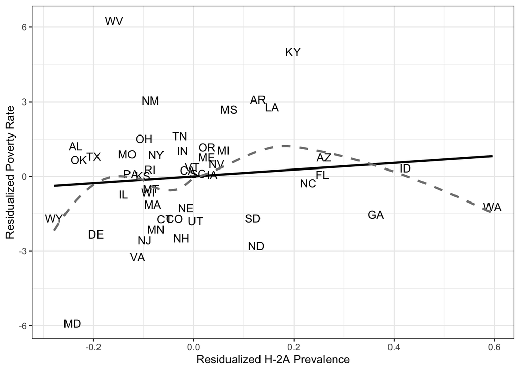

```r
#residualize variables
pov_mod <- lm(per_pov ~ per_hisp + per_black + per_aian + per_ag,
              data = state_sf)
h2a_mod <- update(pov_mod, per_h2a ~ .)
state_sf$pov_star <- residuals(pov_mod)
state_sf$h2a_star <- residuals(h2a_mod)

#plot it!
ggplot(data = state_sf, aes(x = h2a_star, y = pov_star, label = STUSPS)) +
  geom_text() +
  geom_smooth(method = "lm", se = FALSE, linetype = 1, color = "black") +
  geom_smooth(method = "loess", se = FALSE, linetype = 2, color = "grey50") +
  scale_x_continuous("Residualized H-2A Prevalence") +
  scale_y_continuous("Residualized Poverty Rate") +
  theme_bw()
```

As expected, the linear trend is weaker than before. While controlling for (a) racial and ethnic composition and (b) the share of the civilian labor force in agriculture does not completely account for the discrepant observations described above, they are considerably less pronounced.

# Question 6

We know going in that a linear probability model is technically inappropriate for the data at hand. With this in mind, use the `glm` command to estimate a fractional logit model depicting the log-odds of poverty as a function of the prevalence of H-2A workers, controlling for both racial and ethnic composition, as well as the share of civilian labor force employed in agriculture (i.e., re-run the multiple linear regression model above using a fractional logit model). To do this, you will need to construct a new variable equal to the *proportion* of the population in poverty. Based on these results, summarize the relationship between poverty and H-2A prevalence in terms of the average marginal effect of H-2A prevalence using the `avg_slopes` command in the `marginaleffects` packages. Make sure to use HC3 standard errors!

```r
state_sf$prop_pov <- state_sf$per_pov / 100
frac_mod <- lm(prop_pov ~ per_h2a + per_hisp + per_black + per_aian + per_ag,
                family = binomial, data = state_sf)
avg_slopes(frac_mod, variables = "per_h2a", vcov = "HC3")
```

```
##
##     Term Estimate Std. Error     z Pr(>|z|)   S   2.5 % 97.5 %
##  per_h2a   0.0136     0.0225 0.603    0.547 0.9 -0.0305 0.0576
##
## Columns: term, estimate, std.error, statistic, p.value, s.value, conf.low, conf.high
```